# Milestone Report Coursera Data Science Capstone

## 1-INTRODUCTION

This Milestone Report is about exploratory data analysis of the Capstone Project of the Data Science Coursera specialization.

Coursera and SwitfKey are partnering on this project; that apply data science in the area of natural language.

The project uses a large text corpus of documents to predict the next word on preceding input.

The data is extracted and cleaned from files and used with the Shiny application.

Here, we have some information about the corpus of data and prepare a plan to create the predictive model.

## 2-R LIBRARIES

Some R libraries used at this project.

```r
library(stringi) # stats files
library(NLP); library(openNLP)
library(tm) # Text mining
library(rJava)
library(RWeka) # tokenizer - create unigrams, bigrams, trigrams
library(RWekajars)
library(SnowballC) # Stemming
library(RColorBrewer) # Color palettes
library(qdap)
```

```r
library(ggplot2) #visualization
```

## 3 - LOOKING FOR THE DATA

The data is from HC Corpora with access to 4 languages, but only English will be used. The dataset has three files.

- en_US.blogs.txt
- en_US.news.txt
- en_US.twitter.txt.

The data was loaded from Coursera Link to local machine and will be read from local disk.

```r
blogsURL <- file("en_US.blogs.txt", open="rb") # open for reading in binary mode
blogs <- readLines(blogsURL, encoding = "UTF-8", skipNul=TRUE)

newsURL <- file("en_US.news.txt", open = "rb") # open for reading in binary mode
news <- readLines(newsURL, encoding = "UTF-8", skipNul=TRUE)

twitterURL <- file("en_US.twitter.txt", open = "rb") # open for reading in binary mode
twitter <- readLines(twitterURL, encoding = "UTF-8", skipNul=TRUE)
```

## 4 - SOME DATA STATISTICS

Let’s evaluate the Data loaded from Blogs, News and Twitter files.

```r
## Size of Files
file.info("en_US.blogs.txt")$size / 1024^2 # Megabytes
```

```
## [1] 200.4242
```

```r
file.info("en_US.news.txt")$size  / 1024^2 # Megabytes
```

```
## [1] 196.2775
```

```r
file.info("en_US.twitter.txt")$size / 1024^2 # Megabytes
```

```
## [1] 159.3641
```

```r
## Number of lines
length(blogs) # 899,288 lines
```

```
## [1] 899288
```

```r
length(news)  # 1,010,242 lines
```

```
## [1] 1010242
```

```r
length(twitter) # 2,360,148
```

```
## [1] 2360148
```

```r
## Counting the Words
sum(stri_count_words(blogs)) # words at blogs = 37,546,246
```

```
## [1] 37546246
```

```r
sum(stri_count_words(news))  # words at news =  34,762,395
```

```
## [1] 34762395
```

```r
sum(stri_count_words(twitter)) # words at twitter = 30,093,410
```

```
## [1] 30093410
```

```r
## The length of the longest line seen in any of the three en_US data sets: (question 3 of Quiz 1)
max(nchar(blogs)) # [1] 40,833
```

```
## [1] 40833
```

```r
max(nchar(news))  # [1] 11,384
```

```
## [1] 11384
```

```r
max(nchar(twitter)) # [1] 140
```

```
## [1] 140
```

## 5 - DATA SAMPLE (subset)

The data is enormous and could have poor performance in mobile. So, we must create a subset of the data considering the limited resources for test and application. Let’s generate a data sample from the three files (blogs, news, Twitter)

```r
set.seed(65364)
sTwitter <- sample(twitter, size = 5000, replace = TRUE)
sBlogs <- sample(blogs, size = 5000, replace = TRUE)
sNews <- sample(news, size = 5000, replace = TRUE)
sampleTotal <- c(sTwitter, sBlogs, sNews)
length(sampleTotal)
writeLines(sampleTotal, "./finaldata/sampleTotal.txt")
```

The new sample file is composed of 15,000 lines, with 5,000 from from each one of the records selected (from blogs, news, and Twitter)

## 6 - CORPUS AND CLEANING THE DATA

The final text data needs to be cleaned to be used in the word prediction algorithm The objective is to create a cleaned Corpus file or sample of text. This Corpus will be cleaned using methods as removing whitespaces, numbers, UTR, punctuation and so on.

Profanity Words list is from Luis von Ahn’s research group at CMU (http://www.cs.cmu.edu/~biglou/resources/).

The library used here is TM that loads the corpus into memory and allow calls to the methods to clean the data.

### 6.1 - Cleaning the Data

```r
## Using the TM Package to clean the Corpus Text
textCon <- file("./finaldata/sampleTotal.txt")
textCorpus <- readLines(textCon)
textCorpus <- Corpus(VectorSource(textCorpus)) # TM reading the text as lists

## Using the TM Package to clean the text
textCorpus <- tm_map(textCorpus, content_transformer(function(x) iconv(x, to="UTF-8", sub="byte")),mc.cores=1)
textCorpus <- tm_map(textCorpus, content_transformer(tolower), lazy = TRUE) # converting to lowercase
textCorpus <- tm_map(textCorpus, content_transformer(removePunctuation), preserve_intra_word_dashes=TRUE) # removing ponctuation

# Removing Profanity Words
profanityWords = readLines('profanity-words.txt')
textCorpus <- tm_map(textCorpus,removeWords, profanityWords)

textCorpus <- tm_map(textCorpus, content_transformer(removeNumbers)) # removing numbers

## removing URLs
removeURL <- function(x) gsub("http[[:alnum:]]*", "", x)
textCorpus <- tm_map(textCorpus, content_transformer(removeURL))

textCorpus <- tm_map(textCorpus, removeWords, stopwords("english")) # removing stop words in English (a, as, at, so, etc.)

textCorpus <- tm_map(textCorpus, stripWhitespace) ## Stripping unnecessary whitespace from document

## Convert Corpus to plain text document
textCorpus <- tm_map(textCorpus, PlainTextDocument)
## showing some lines of the textcorpus
## for (i in 1:10){
##  print(textCorpus[[i]]$content)
##}

## Saving the final corpus
saveRDS(textCorpus, file = "./finaldata/finalCorpus.RData")
```

## 7 - TOKENIZATION

Let’s read the text to break it into words and sentences, and to turn it into n-grams. These are all called tokenization because we are breaking up the text into units of meaning, called tokens.

In Natural Language Processing (NLP), *n*-gram is a contiguous sequence of n items from a given sequence of text or speech. Unigrams are single words. Bigrams are two words combinations. Trigrams are three-word combinations.

The tokenizer method is allowed in R using the package RWeka. The following function is used to extract 1-grams, 2-grams, 3-grams and 4-grams from the text Corpus using RWeka.

- 7.1 - Obtaining the uniGrams

```r
## Tokenizer function to get unigrams
unigram <- NGramTokenizer(finalCorpus, Weka_control(min = 1, max = 1,delimiters = " \\r\\n\\t.,;:\"()?!"))
unigram <- data.frame(table(unigram))
unigram <- unigram[order(unigram$Freq,decreasing = TRUE),]

names(unigram) <- c("word1", "freq")

unigram$word1 <- as.character(unigram$word1)

write.csv(unigram[unigram$freq > 1,],"unigram.csv",row.names=F)
unigram <- read.csv("unigram.csv",stringsAsFactors = F)
saveRDS(unigram, file = "unigram.RData")
```

** Plotting UNIGRAM

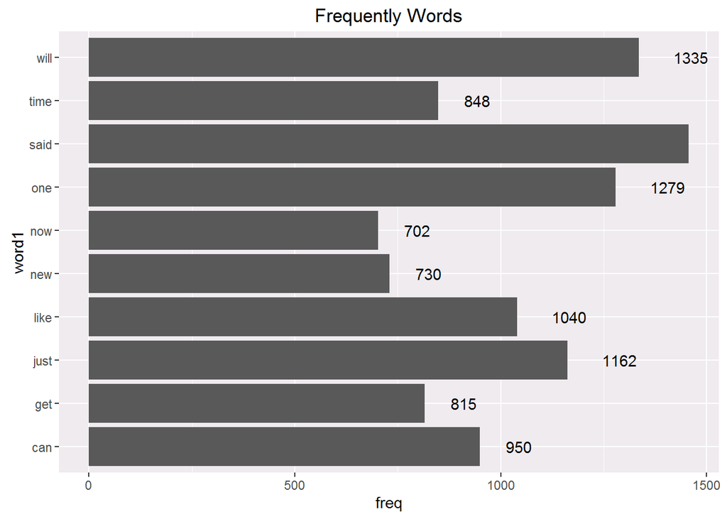

```r
## Unigram Plot
unigram <- readRDS("unigram.RData")
g1 <- ggplot(data=unigram[1:10,], aes(x = word1, y = freq))
g2 <- g1 + geom_bar(stat="identity") + coord_flip() + ggtitle("Frequently Words")
g3 <- g2 + geom_text(data = unigram[1:10,], aes(x = word1, y = freq, label = freq), hjust=-1, position = "identity")
g3
```

- 7.2 - Obtaining the biGrams

```r
# Tokenizer function to get bigrams
bigram <- NGramTokenizer(finalCorpus, Weka_control(min = 2, max = 2,delimiters = " \\r\\n\\t.,;:\"()?!"))
bigram <- data.frame(table(bigram))
bigram <- bigram[order(bigram$Freq,decreasing = TRUE),]
names(bigram) <- c("words","freq")
bigram$words <- as.character(bigram$words)
str2 <- strsplit(bigram$words,split=" ")
bigram <- transform(bigram,
                    one = sapply(str2,"[[",1),
                    two = sapply(str2,"[[",2))
bigram <- data.frame(word1 = bigram$one,word2 = bigram$two,freq = bigram$freq,stringsAsFactors=FALSE)

## saving files
write.csv(bigram[bigram$freq > 1,],"bigram.csv",row.names=F)
bigram <- read.csv("bigram.csv",stringsAsFactors = F)
saveRDS(bigram,"bigram.RData")
```

- 7.3 - Obtaining the triGrams

```r
# Tokenizer function to get trigrams
trigram <- NGramTokenizer(finalCorpus, Weka_control(min = 3, max = 3,delimiters = " \\r\\n\\t.,;:\"()?!"))
trigram <- data.frame(table(trigram))
trigram <- trigram[order(trigram$Freq,decreasing = TRUE),]
head(trigram)
```

```
##                          trigram Freq
## 24220         bmw service center   22
## 184025 service center california   22
## 138310             new york city   18
## 37426       city kansas missouri   10
## 107435      kansas missouri news   10
## 131043   missouri news televison   10
```

```r
names(trigram) <- c("words","freq")
head(trigram)
```

```
##                            words freq
## 24220         bmw service center   22
## 184025 service center california   22
## 138310             new york city   18
## 37426       city kansas missouri   10
## 107435      kansas missouri news   10
## 131043   missouri news televison   10
```

```r
#####################
trigram$words <- as.character(trigram$words)
str3 <- strsplit(trigram$words,split=" ")
trigram <- transform(trigram,
                     one = sapply(str3,"[[",1),
                     two = sapply(str3,"[[",2),
                     three = sapply(str3,"[[",3))
# trigram$words <- NULL
trigram <- data.frame(word1 = trigram$one,word2 = trigram$two,
                      word3 = trigram$three, freq = trigram$freq,stringsAsFactors=FALSE)
# saving files
write.csv(trigram[trigram$freq > 1,],"trigram.csv",row.names=F)
trigram <- read.csv("trigram.csv",stringsAsFactors = F)
saveRDS(trigram,"trigram.RData")
```

- 7.4 - Obtaining the quadGrams

```r
# Tokenizer function to get quadgrams
quadgram <- NGramTokenizer(finalCorpus, Weka_control(min = 4, max = 4,delimiters = " \\r\\n\\t.,;:\"()?!"))
quadgram <- data.frame(table(quadgram))
quadgram <- quadgram[order(quadgram$Freq,decreasing = TRUE),]

names(quadgram) <- c("words","freq")
quadgram$words <- as.character(quadgram$words)

str4 <- strsplit(quadgram$words,split=" ")
quadgram <- transform(quadgram,
                      one = sapply(str4,"[[",1),
                      two = sapply(str4,"[[",2),
                      three = sapply(str4,"[[",3),
                      four = sapply(str4,"[[",4))
# quadgram$words <- NULL
quadgram <- data.frame(word1 = quadgram$one,
                       word2 = quadgram$two,
                       word3 = quadgram$three,
                       word4 = quadgram$four,
                       freq = quadgram$freq, stringsAsFactors=FALSE)
# saving files
write.csv(quadgram[quadgram$freq > 1,],"quadgram.csv",row.names=F)
quadgram <- read.csv("quadgram.csv",stringsAsFactors = F)
saveRDS(quadgram,"quadgram.RData")
```

## 8 - NEXT STEPS

### 8.1 - Considerations

- All the process from reading the file, cleaning and creating the n-grams is time-consuming for your computer.
- NLP uses intensive computer resource and is necessary a lot of tests get n-grams efficient keeping minimum files sizes.
- The techniques of removing words (cleaning) sometimes is not precise as we can suppose.
- Increasing the quality of n-gram tokenization could be critical to prediction accuracy at the prediction algorithm.

### 8.1 - Next Steps

- Build a Shiny app to allow the user input the word to obtain a suggestion of the next word.
- Develop the prediction algorithm implemented in Shiny app.
- Prepare a pitch about the app and publish it at “shinyapps.io” server.